# Module 3 Review

## Putting It All Together

- Relationships between continuous variables.
- Correlation:
  - Unitless measure of linear (Pearson’s) or monotonic (Spearman’s) pairwise relationships.
    - Does not *adjust* for other variables.
  - Quantifies strength and direction of relationship.
    - Allows us to compare strength of relationships across different pairs of variables.
- Linear regression:
  - Models relationship between continuous outcome and one *or more* predictors.
    - Units are attached, so the relationship can be stated in context.
  - Provides estimates of association *adjusted* for other variables in the model.
  - Allows for prediction of outcome based on predictor values.

## Example

- During a puzzle-heavy session in Ponyville, Twilight wants to understand what helps small teams solve logic puzzles faster. For each puzzle, she records:
  - *MindPractice*: hours of individual “mind” drills the day before.
  - *SleepHours*: hours slept the night before.
  - *FocusMinutes*: minutes of calm focus/box-breathing right before starting.
  - *PuzzleComplexity*: a continuous difficulty score Twilight assigns from 1–10.
  - *SolveTime* — minutes to solve the puzzle (lower is better).
- Our task is to determine how MindPractice, SleepHours, FocusMinutes, and PuzzleComplexity relate to SolveTime.

## Example

- Let’s first look at pairwise scatterplots.

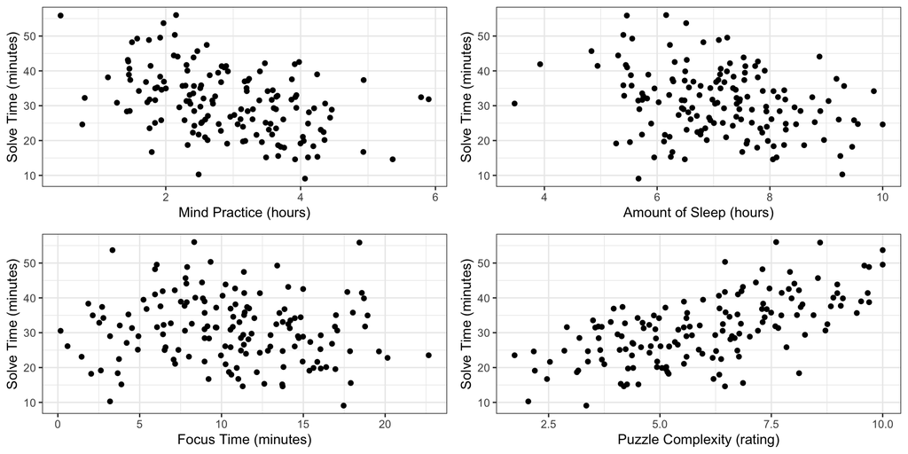

## Example

- Next, let’s determine what method of correlation we should use. Checking normality,

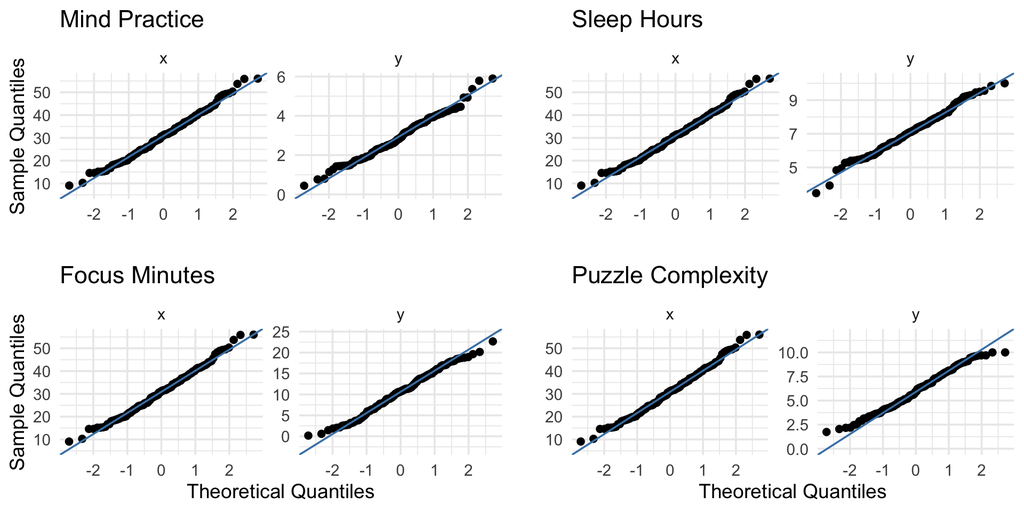

## Example

- Because we met the normality assumption, we can use Pearson’s correlation to quantify pairwise relationships.

| var1 | var2 | correlation | test_statistic | p_value |
| --- | --- | --- | --- | --- |
| MindPractice | SolveTime | -0.417 | -5.575 | < 0.001 |
| SleepHours | SolveTime | -0.272 | -3.433 | < 0.001 |
| FocusMinutes | SolveTime | -0.101 | -1.234 | 0.219 |
| PuzzleComplexity | SolveTime | 0.637 | 10.047 | < 0.001 |

## Example

- Because we met the normality assumption, we can use Pearson’s correlation to quantify pairwise relationships.

|  | var1 | var2 | correlation | test_statistic | p_value |
| --- | --- | --- | --- | --- | --- |
| 1 | SolveTime | MindPractice | -0.417 | -5.575 | < 0.001 |

- Mind practice is significantly correlated with solve time ($p < 0.001$).
  - The correlation is negative and modest ($r \approx -0.42$), indicating that increased mind practice is associated with decreased solve times (i.e., they are faster to solve).

## Example

- Because we met the normality assumption, we can use Pearson’s correlation to quantify pairwise relationships.

|  | var1 | var2 | correlation | test_statistic | p_value |
| --- | --- | --- | --- | --- | --- |
| 1 | SolveTime | SleepHours | -0.272 | -3.433 | < 0.001 |

- Sleep duration is significantly correlated with solve time ($p < 0.001$).
  - The correlation is negative and weak ($r \approx -0.27$), indicating that increased sleep duration is associated with decreased solve times (i.e., they are faster to solve).

## Example

- Because we met the normality assumption, we can use Pearson’s correlation to quantify pairwise relationships.

|  | var1 | var2 | correlation | test_statistic | p_value |
| --- | --- | --- | --- | --- | --- |
| 1 | SolveTime | FocusMinutes | -0.101 | -1.234 | 0.219 |

- Focus is not significantly correlated with solve time ($p = 0.219$).
  - The correlation is negative and weak ($r \approx -0.10$), indicating that increased focus is associated with decreased solve times (i.e., they are faster to solve).

## Example

- Because we met the normality assumption, we can use Pearson’s correlation to quantify pairwise relationships.

|  | var1 | var2 | correlation | test_statistic | p_value |
| --- | --- | --- | --- | --- | --- |
| 1 | SolveTime | PuzzleComplexity | 0.637 | 10.047 | < 0.001 |

- Puzzle complexity is significantly correlated with solve time ($p < 0.001$).
  - The correlation is positive and modest ($r \approx 0.64$), indicating that increased complexity is associated with increased solve times (i.e., they are slower to solve).

## Example

- Let’s now examine the multiple regression model,

| term | estimate | std_error | statistic | lower_bound | upper_bound | p_value |
| --- | --- | --- | --- | --- | --- | --- |
| (Intercept) | 37.53909079 | 3.5912111 | 10.4530450 | 30.4412073 | 44.6369742 | < 0.001 |
| MindPractice | -4.12421234 | 0.4558822 | -9.0466622 | -5.0252451 | -3.2231796 | < 0.001 |
| SleepHours | -1.82209182 | 0.3864501 | -4.7149472 | -2.5858948 | -1.0582888 | < 0.001 |
| FocusMinutes | -0.01761189 | 0.0974355 | -0.1807543 | -0.2101892 | 0.1749654 | 0.857 |
| PuzzleComplexity | 3.09727436 | 0.2376419 | 13.0333690 | 2.6275848 | 3.5669639 | < 0.001 |

- This gives the regression model,

$$\hat{\text{solve time}} = 37.54 - 4.12 \text{ practice} - 1.82 \text{ sleep} - 0.02 \text{ focus} + 3.10 \text{ complexity}$$

## Example

- If I were reporting the table of results, I would submit

| Predictor | Estimate (95% CI) | p-value |
| --- | --- | --- |
| Mind Practice | -4.12 (-5.02, -3.22) | <0.001 |
| Sleep Hours | -1.82 (-2.58, -1.06) | <0.001 |
| Focus Minutes | -0.02 (-0.21, 0.17) | 0.857 |
| Puzzle Complexity | 3.10 (2.63, 3.57) | <0.001 |

## Example

- Before we make inference on each predictor, let’s examine the significance of the regression model.

```
Likelihood Ratio Test for Significant Regression Line:
Null: H₀: β₁ = β₂ = ... = βₖ = 0
Alternative: H₁: At least one βᵢ ≠ 0
Test statistic: χ²(4) = 8661.511
p-value: p < 0.001
Conclusion: Reject the null hypothesis (p = < 0.001 < α = 0.05)
```

## Example

- **Hypotheses**
  - $H_0: \beta_{\text{mind}} = \beta_{\text{sleep}} = \beta_{\text{focus}} = \beta_{\text{complex}} = 0$
  - $H_1:$ at least one $\beta_i \ne 0$
- **Test Statistic and *p*-Value**
  - $\chi^2_0 = 8661.51$; $p < 0.001$
- **Rejection Region**
  - Reject $H_0$ if $p<\alpha$; $\alpha=0.05$
- **Conclusion and Intepretation**
  - Reject $H_0$. There is sufficient evidence to conclude that at least one of the predictors is significantly associated with solve time, after adjusting for the other predictors.

## Example

- Now, let’s provide some interpretations and comment on significance.

| Predictor | Estimate (95% CI) | p-value |
| --- | --- | --- |
| Mind Practice | -4.12 (-5.02, -3.22) | <0.001 |
| Sleep Hours | -1.82 (-2.58, -1.06) | <0.001 |
| Focus Minutes | -0.02 (-0.21, 0.17) | 0.857 |
| Puzzle Complexity | 3.10 (2.63, 3.57) | <0.001 |

- Mind practice is significantly associated with solve time ($p < 0.001$). After adjusting for sleep, focus, and complexity, each additional hour of mind practice is associated with a decrease in solve time of approximately 4.12 minutes (95% CI: -5.02, -3.22).

## Example

- Now, let’s provide some interpretations and comment on significance.

| Predictor | Estimate (95% CI) | p-value |
| --- | --- | --- |
| Mind Practice | -4.12 (-5.02, -3.22) | <0.001 |
| Sleep Hours | -1.82 (-2.58, -1.06) | <0.001 |
| Focus Minutes | -0.02 (-0.21, 0.17) | 0.857 |
| Puzzle Complexity | 3.10 (2.63, 3.57) | <0.001 |

- Sleep hours is significantly associated with solve time ($p < 0.001$). After adjusting for mind practice, focus, and complexity, each additional hour of sleep is associated with a decrease in solve time of approximately 1.82 minutes (95% CI: -2.58, -1.06).

## Example

- Now, let’s provide some interpretations and comment on significance.

| Predictor | Estimate (95% CI) | p-value |
| --- | --- | --- |
| Mind Practice | -4.12 (-5.02, -3.22) | <0.001 |
| Sleep Hours | -1.82 (-2.58, -1.06) | <0.001 |
| Focus Minutes | -0.02 (-0.21, 0.17) | 0.857 |
| Puzzle Complexity | 3.10 (2.63, 3.57) | <0.001 |

- Focus minutes is not significantly associated with solve time ($p = 0.857$). After adjusting for mind practice, sleep, and complexity, each additional minute of focus is associated with a decrease in solve time of approximately 0.02 minutes (95% CI: -0.21, 0.17).

## Example

- Now, let’s provide some interpretations and comment on significance.

| Predictor | Estimate (95% CI) | p-value |
| --- | --- | --- |
| Mind Practice | -4.12 (-5.02, -3.22) | <0.001 |
| Sleep Hours | -1.82 (-2.58, -1.06) | <0.001 |
| Focus Minutes | -0.02 (-0.21, 0.17) | 0.857 |
| Puzzle Complexity | 3.10 (2.63, 3.57) | <0.001 |

- Puzzle complexity is significantly associated with solve time ($p < 0.001$). After adjusting for mind practice, sleep, and focus, each additional unit increase in puzzle complexity is associated with an increase in solve time of approximately 3.10 minutes (95% CI: 2.63, 3.57).

## Example

- Let’s create a visualization of the model.
  - We know that solve time will be on the *y*-axis.
  - We can choose one predictor to put on the *x*-axis – let’s choose sleep duration.
  - The other predictors will be set to their median values.

```
# A tibble: 5 × 3
  variable         mean_sd    median_iqr
  <chr>            <chr>      <chr>
1 FocusMinutes     10.6 (4.7) 10.7 (6.8)
2 MindPractice     2.9 (1.0)  2.8 (1.4)
3 PuzzleComplexity 6.0 (1.9)  5.9 (3.0)
4 SleepHours       7.1 (1.2)  7.1 (1.6)
5 SolveTime        30.9 (9.4) 31.1 (12.5)
```

## Example

- Our first step is to create predicted values using the found regression model.
  - Let sleep duration vary.
  - Plug in medians for other predictors.

$$\hat{\text{solve time}} = 37.54 - 4.12 \text{ practice} - 1.82 \text{ sleep} - 0.02 \text{ focus} + 3.10 \text{ complexity}$$

```r
puzzles <- puzzles %>%
  mutate(predicted = 37.54 - 4.12 * median(MindPractice)
                           - 1.82 * SleepHours
                           - 0.02 * median(FocusMinutes)
                           + 3.10 * median(PuzzleComplexity))
```

## Example

- Then we can graph.
  - Scatterplot: *x* = SleepHours, *y* = SolveTime
  - Line: *x* = SleepHours, *y* = predicted

```r
puzzles %>% ggplot(aes(x = SleepHours, y = SolveTime)) + # specify x and y
  geom_point(size = 2.5, color = "gray50") + # plot points
  geom_line(aes(y = predicted), linewidth = 1, color = "black") + # plot line
  labs(x = "Sleep Duration (hours)", # edit x-axis label
       y = "Time to Complete Puzzle (min)") + # edit y-axis label
  theme_bw() # change theme of graph
```

## Example

- The resulting graph,

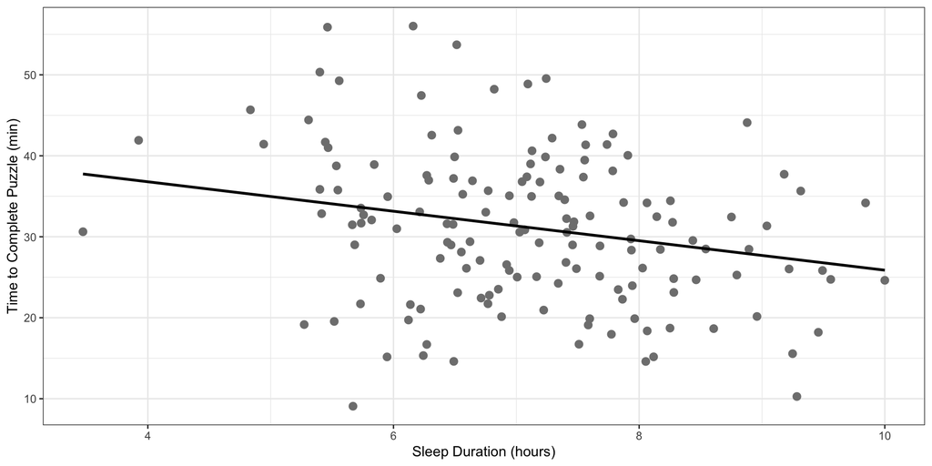

## Wrap Up

- This module covers the basics of linear regression.
- As a reminder, this is just the beginning. There are many more advanced topics to explore, including:
  - Interaction terms
  - Nonlinear relationships
  - Model selection
  - Diagnostics and remedial measures
- STA4231 - Statistics for Data Science II dives deeper into regression topics.